# HW6

Elif Konyar

6/10/2020

# CONTINOUS TYPE HOPFIELD MODEL ASSIGNMENT

In this assignment, two-neuron continuous type hopfield model is implemented. The T matrix is as follows:
$$T=
\left[ {\begin{array}{cc}
0 & 1 \\
1 & 0 \\
\end{array} } \right]$$

The nonlinear activation function is:

$$\begin{equation}
v=g(u)=2/\pi\ arctan((\lambda \pi u)/2)
\end{equation}$$

## Question 1

In the first question, the equilibrium points for the given system are found. It is known that in the equilibrium points $dE/dt=0$. So, the energy is minimized in the equilibrium points where $dE/dt=0$. We know from the lectures that

$$\begin{equation}
\frac{dE}{dt}=- \sum_{i}C_i (\frac{dv}{dt})^2 \frac{dg^{-1}(v_i)}{dv_i}
\end{equation}$$

In this equation, $dv/dt$ should be 0 since $g^{-1}(v_i)$ is an increasing function which means its derivative is positive. Thus, $dv/dt=0$ should be satisfied in order $dE/dt=0$ to be satisfied.

The v function is given above. Thus, the derivative is:

$$\begin{equation}
\frac{dv}{dt}= \frac{dg(u)}{dt} = \frac{2}{\pi}g^{'}(u)\frac{du}{dt}= \lambda \frac{1}{1+(\frac{\lambda}{2}\pi u)^2} \frac{du}{dt}
\end{equation}$$

So, in order $dv/dt$ to be 0, $du/dt$ should be 0.

Apart from these, we have the following resistance-capacitance charging equations:

$$\begin{equation}
C_i \frac{du_i}{dt} + \frac{u_i}{R_i}= \sum_{j}T_{ij}V_j +I_i
\end{equation}$$

where $C_i$ and $R_i$ are 1 and $I_i$ is 0.

From those with the given T matrix, we can say that
$$\begin{equation}
\frac{du_1}{dt}=v_2-u_1
\end{equation}$$
and
$$\begin{equation}
\frac{du_2}{dt}=v_1-u_2
\end{equation}$$

In order to find the equilibrium points, we need to solve the above 2 equations by finding the roots of the right hand sides since $du/dt$ is 0.

The simplified version of the above equations by replacing $u_1$ with $v_2$ and vice versa is:
$$\begin{equation}
g(g(u_2))-u_2=0
\end{equation}$$
and
$$\begin{equation}
g(g(u_1))-u_1=0
\end{equation}$$

```r
library(rootSolve)
library(data.table)
library(ggplot2)
t_matrix=matrix(c(0,1,1,0),nrow=2,ncol=2)
```

The necessary functions are defined below:

```r
#calculation of g(u)
calculate_v=function(lambda,u){
  return((2/pi)*atan((lambda*pi*u)/2))
}

#calculation of g^-1(v)
calculate_u=function(lambda,v){
  2/(lambda*pi)*(tan(pi*v/2))
}

#the function that I will find the roots of:
find_u=function(lambda,u){
  calculate_v(lambda,calculate_v(lambda,u))-u
}
```

The lambda is taken as 1.4.

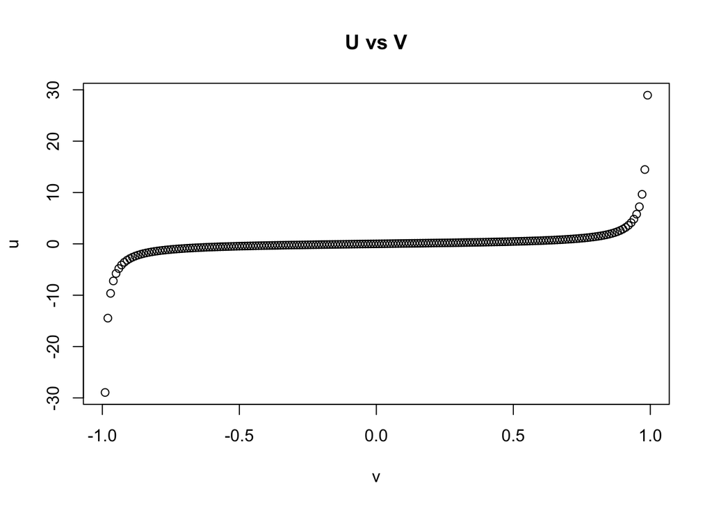

```r
v_range=seq(-0.99,0.99,by=0.01)
u_range=calculate_u(lambda=1.4,v_range)
plot(v_range,u_range, xlab="v", ylab="u", main="U vs V")
```

```r
u_range
```

```
##   [1] -28.946528621 -14.469692588  -9.642492623  -7.227701086  -5.777872262
##   [6]  -4.810524088  -4.118878400  -3.599546000  -3.195088335  -2.871042180
##  [11]  -2.605476302  -2.383769799  -2.195800431  -2.034337958  -1.894080137
##  [16]  -1.771050221  -1.662207111  -1.565185449  -1.478117794  -1.399510138
##  [21]  -1.328152997  -1.263056745  -1.203403816  -1.148512858  -1.097811492
##  [26]  -1.050815352  -1.007111789  -0.966347058  -0.928216168  -0.892454752
##  [31]  -0.858832514  -0.827147905  -0.797223768  -0.768903748  -0.742049321
##  [36]  -0.716537317  -0.692257843  -0.669112534  -0.647013080  -0.625879961
##  [41]  -0.605641377  -0.586232332  -0.567593835  -0.549672222  -0.532418560
##  [46]  -0.515788134  -0.499739996  -0.484236572  -0.469243317  -0.454728409
##  [51]  -0.440662485  -0.427018399  -0.413771016  -0.400897020  -0.388374751
##  [56]  -0.376184056  -0.364306152  -0.352723510  -0.341419747  -0.330379528
##  [61]  -0.319588478  -0.309033108  -0.298700734  -0.288579423  -0.278657927
##  [66]  -0.268925631  -0.259372505  -0.249989058  -0.240766299  -0.231695697
##  [71]  -0.222769149  -0.213978947  -0.205317749  -0.196778554  -0.188354674
```

[output cut: 25 more lines]

I will take the u range as [-14.469692588,14.469692588] since there are only 1 point apart from those ranges. Also, the below function (uniroot.all) gives error when the boundary is given due to derivatives I think.

```r
#finding equilibrium points
roots=uniroot.all(find_u, c(-14.469692588,14.469692588),tol = 0.01,lambda=1.4)
roots
```

```
## [1]  0.0000000 -0.5728623  0.5728623
```

```r
v=calculate_v(lambda=1.4,roots)
v
```

```
## [1]  0.0000000 -0.5728672  0.5728672
```

Below is to find the energy when a state is given. It is the simplified version. The energy function is:

$$\begin{equation}
E=- \frac{1}{2} \sum_{i}\sum_{j}T_{ij}V_iV_j+\sum_{i}\frac{1}{R_i} \int_{0}^{v_i}g^{'}(\zeta)d\zeta-\sum_{i}I_iV_i
\end{equation}$$

where the last part is 0 since $I_i$ is taken as 0.

```r
#energy function
calculate_integral= Vectorize(function(z,lambda) integrate(calculate_u, lower = 0, upper = z,lambda=lambda)$value)

#calculate_integral(0.5,1.4)
lambda=1.4
energy=function(v1,v2,lambda){
  (-1/2)*(t_matrix[1,2]*v1*v2+t_matrix[2,1]*v2*v1)+calculate_integral(v1,lambda)+calculate_integral(v2,lambda)
}
```

Since this is done due to finding the points where $dE/dt$ is 0, the solution can also find the maximum points in addition to the minimum points. We know that in the stable equilibrium points, the energy reaches to its minimum. So, below I calculate the energy values of the roots that I found.

Below the root u values and the corresponding v values are found.

```r
roots
```

```
## [1]  0.0000000 -0.5728623  0.5728623
```

```r
v
```

```
## [1]  0.0000000 -0.5728672  0.5728672
```

Since
$$\begin{equation}
g(u_2)-u_1=v_2-u_1=0
\end{equation}$$
should be satisfied, when v is -0.5728672, the other u should be of the same sign.

```r
v[1]
```

```
## [1] 0
```

```r
energy(v[1],v[1],lambda)
```

```
## [1] 0
```

```r
v[2]
```

```
## [1] -0.5728672
```

```r
energy(v[2],v[2],lambda)
```

```
## [1] -0.05300983
```

```r
v[3]
```

```
## [1] 0.5728672
```

```r
energy(v[3],v[3],lambda)
```

```
## [1] -0.05300983
```

```r
eq_points=v[2:3]
eq_points_u=roots[2:3]
```

Below, we can see the contour plots. For this task, v range is created and the corresponding energy values are calculated. Then, for the given energy values, the contour plots are drawn. The energy values of the contours from the outside to inside are 0.449, 0.156, 0.017, -0.003, -0.023, -0.041. The black dots show the equilibrium points.

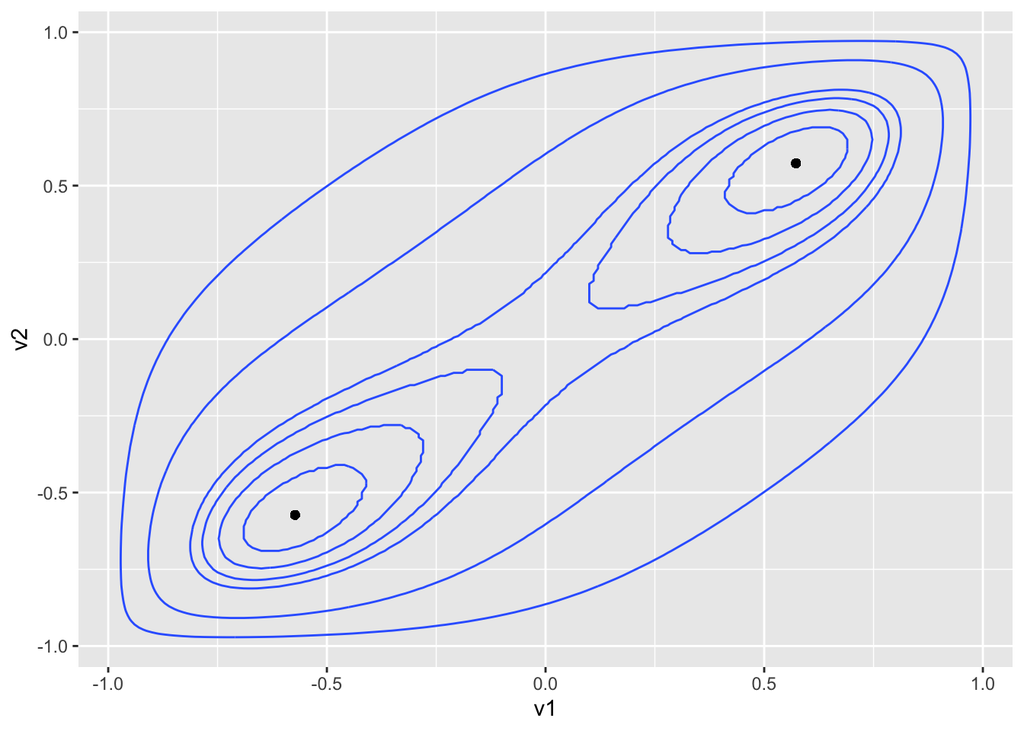

```r
#contourplots
v1_range=seq(-0.99,0.99,by=0.01)
v2_range=seq(-0.99,0.99,by=0.01)
v_pairs=as.data.table(merge(v1_range,v2_range))
setnames(v_pairs,old=c("x","y"),new=c("v1","v2"))
v_pairs[,energy:=energy(v1,v2,lambda)]
v_pairs[,energy:=round(energy,3)]


contour1 <- ggplot(v_pairs, aes(v1, v2, z = energy))
contour1=contour1+stat_contour(breaks=c(0.449,0.156,0.017,-0.003,-0.023,-0.041))
contour1+geom_point(aes(x=eq_points[1],y=eq_points[1]))+geom_point(aes(x=eq_points[2],y=eq_points[2]))
```

## Question 2

In this question, we are asked to simulate this dynamic system with an initial state close to one of the stable equilibrium points. For the starting points I added random noise distributed uniformly between -0.2 and 0.2 to the equilibrium points. Lambda is again taken as 1.4. The learning rate is taken as 0.1.

The u’s are updated with the following formula:

$$\begin{equation}
u_{i new}=u_{i old}+learningrate \frac{du_i}{dt}
\end{equation}$$

```r
#starting very close to positive v's
set.seed(135)
initial_u1=eq_points_u[2]
initial_u2=eq_points_u[2]

u1=initial_u1+runif(1,-0.2,0.2)
u2=initial_u2+runif(1,-0.2,0.2)
lambda=1.4
learning_rate=0.1
v1=calculate_v(lambda=lambda,u1)
v2=calculate_v(lambda=lambda,u2)

stopping_cond=0.0001
```

Below, the trajectory is found with the update rule. The v’s are calculated again with calculate_v function.

```r
v_trajectory=data.table()
v_trajectory=rbind(v_trajectory,data.table(v1=v1,v2=v2))
is_stopped=F
while(is_stopped==F){
  v1_old=copy(v1)
  v2_old=copy(v2)
  delta_u1=1*v2-u1
  delta_u2=1*v1-u2
  u1=u1+learning_rate*delta_u1
  u2=u2+learning_rate*delta_u2
  v1=calculate_v(lambda=lambda,u1)
  v2=calculate_v(lambda=lambda,u2)
  v_trajectory=rbind(v_trajectory,data.table(v1=v1,v2=v2))
  if(((v2-v2_old)<stopping_cond) & ((v1-v1_old)<stopping_cond)){
    is_stopped=T
  }
}
v_trajectory[,energy:=energy(v1,v2,lambda)]
v_pairs_q2=copy(v_pairs)
v_pairs_q2=rbind(v_pairs_q2,v_trajectory)
```

Below is the contour plot and the trajectory of the new point converging to the (0.5728672,0.5728672). The red dots show the trajectory.

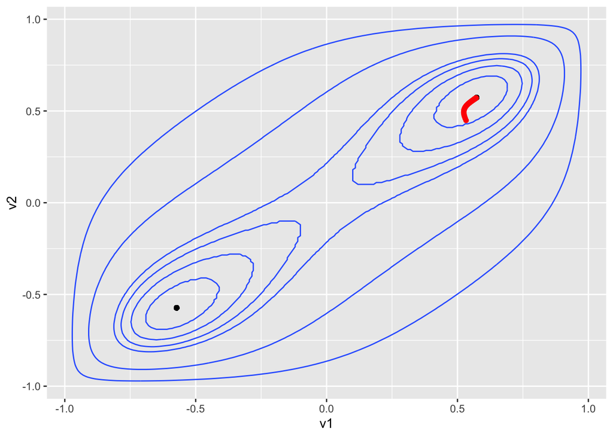

```r
contour1 <- ggplot(v_pairs_q2[1:(nrow(v_pairs_q2)-nrow(v_trajectory))], aes(v1, v2, z = energy))
contour1=contour1+stat_contour(breaks=c(0.449,0.156,0.017,-0.003,-0.023,-0.041))
contour1 +
  geom_point(aes(x=eq_points[1],y=eq_points[1])) +
  geom_point(aes(x=eq_points[2],y=eq_points[2])) +
  geom_point(data=v_pairs_q2[(nrow(v_pairs_q2)-nrow(v_trajectory)+1):nrow(v_pairs_q2)],aes(x=v1, y=v2,z=energy), colour="red")
```

## Question 3

In this question, the relation between Discrete Hopfield Model and Continuous Hopfield Model is observed by changing the lambda value. As lambda is increasing, the model is expected to become more like Discrete Hopfield Model since the second part in the energy function which is the integral part goes to zero which makes the energy function same as with the one of the discrete model.

Below, the roots are found for each lambda value. Lambda increase is 0.1. I took the iteration number as 1000 and with this iteration number, the equilibrium points look like they converged to the corners. So, I did not continue after this iteration. So, I guess that lamda value is large enough for this system.

```r
#finding equilibrium points
roots_history=data.table()
for(i in 1:1000){
  roots=uniroot.all(find_u, c(-14.469692588,14.469692588),tol = 0.01,lambda=1.4+i*0.1)
  roots_history=rbind(roots_history,cbind(data.table(t(roots)),data.table(lambda=1.4+i*0.1)))
}
```

Below, the v values are calculated with the same procedure satisfying the following equation:

$$\begin{equation}
g(u_2)-u_1=v_2-u_1=0
\end{equation}$$

The contour plots can be seen below. It can be observed that the stable equilibrium points converged to the corners of the hypercube.

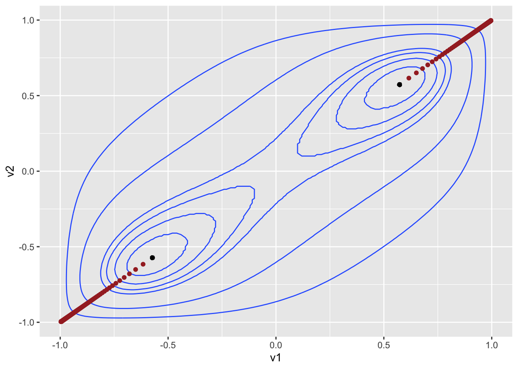

```r
roots_history=rbind(roots_history[,.(u1=V2,u2=V2,lambda)],roots_history[,.(u1=V3,u2=V3,lambda)])
roots_history[,v1:=calculate_v(lambda,u1)]
roots_history[,v2:=calculate_v(lambda,u2)]
roots_history[,energy:=energy(v1,v2,lambda=lambda)]
roots_history=roots_history[,.(v1,v2,energy)]
v_pairs=rbind(v_pairs,roots_history)

contour1 <- ggplot(v_pairs[1:(nrow(v_pairs)-nrow(roots_history))], aes(v1, v2, z = energy))
contour1=contour1+stat_contour(breaks=c(0.449,0.156,0.017,-0.003,-0.023,-0.041))
contour1 +
  geom_point(aes(x=eq_points[1],y=eq_points[1])) +
  geom_point(aes(x=eq_points[2],y=eq_points[2])) +
  geom_point(data=v_pairs[(nrow(v_pairs)-nrow(roots_history)+1):nrow(v_pairs)],aes(x=v1, y=v2,z=energy),col="brown")
```